# EDA for Skill Extraction from Job Descriptions: 5k Training vs External Validation

Lincoln Chanakira

This exploratory analysis supports the research question:

> How well can skills be extracted or predicted from LinkedIn job descriptions, job titles, and related profile text?

The analysis compares the two datasets used in the final CP8 modeling and external validation workflow:

- The 5k LinkedIn dataset used for training and internal testing.
- The KSB alumni + LinkedIn external validation dataset used for out-of-sample validation.

The main EDA focus is:

- Dataset dimensions.
- Total number of skill assignments.
- Number of unique skills.
- Skills per profile.
- Job-description text availability.
- Skill overlap between the 5k training data and external validation data.
- Label imbalance and top-skill concentration.
- Coverage of the 100 modeled skills in the external validation dataset.
- TF-IDF vocabulary and sparsity diagnostics.
- Text-to-skill signal checks using token-skill association.
- Skill co-occurrence patterns for multi-label modeling.
- Train-vs-external validation drift diagnostics.
- Model-readiness risks and practical recommendations.

These measures show whether the 5k training data has enough label coverage for modeling and whether the external validation dataset is comparable enough for a fair out-of-sample check.

# Load Packages and Paths

```r
library(readr)
library(dplyr)
library(tidyr)
library(stringr)
library(purrr)
library(ggplot2)
library(tidytext)
library(scales)
library(tibble)
library(forcats)
```

```r
processed_dir <- file.path("..", "data", "processed")
eda_dir <- file.path("..", "results", "skills_extraction_eda_5k_external")

dir.create(eda_dir, recursive = TRUE, showWarnings = FALSE)
```

# Helper Functions

```r
# Normalize text so token and skill comparisons are consistent across datasets.
clean_text_for_eda <- function(x) {
  x <- ifelse(is.na(x), "", as.character(x))
  x <- str_to_lower(x)
  x <- str_replace_all(x, "[\r\n\t]+", " ")
  x <- str_replace_all(x, "[[:punct:]]+", " ")
  x <- str_replace_all(x, "\\s+", " ")
  str_squish(x)
}

# Convert comma/semicolon/pipe-separated skill strings into unique skill vectors.
split_skill_string <- function(x) {
  x <- ifelse(is.na(x), "", as.character(x))
  x <- str_to_lower(x)
  x <- str_replace_all(x, "\\s*[,;|]\\s*", ",")
  str_split(x, ",") |>
    map(~ {
      skills <- str_squish(.x)
      skills <- skills[skills != ""]
      unique(skills)
    })
}

count_words <- function(x) {
  str_count(ifelse(is.na(x), "", as.character(x)), "\\S+")
}

collapse_row_text <- function(df, columns) {
  if (length(columns) == 0) {
    return(rep("", nrow(df)))
  }

  df |>
    select(all_of(columns)) |>
    mutate(across(everything(), as.character)) |>
    pmap_chr(function(...) {
      values <- c(...)
      values <- values[!is.na(values) & values != ""]
      paste(values, collapse = " ")
    })
}

make_dataset_summary <- function(df) {
  df |>
    group_by(dataset) |>
    summarise(
      profiles = n(),
      profiles_with_skills = sum(skill_count > 0),
      pct_profiles_with_skills = mean(skill_count > 0) * 100,
      avg_skills_per_profile = mean(skill_count),
      median_skills_per_profile = median(skill_count),
      avg_profile_tokens = mean(profile_token_count),
      median_profile_tokens = median(profile_token_count),
      pct_profiles_with_current_description = mean(has_current_job_description) * 100,
      pct_profiles_with_previous_description = mean(has_previous_job_description) * 100,
      avg_experience_count = mean(total_experience_count, na.rm = TRUE),
      .groups = "drop"
    )
}
```

# Load and Harmonize Datasets

```r
# The 5k dataset is the primary training dataset used by the CP8 modeling
# workflow. It already contains cleaned profile_text and parsed skill counts.
data_5k_path <- file.path(processed_dir, "linkedin_full_5865_preprocessed.csv")
data_5k_raw <- read_csv(data_5k_path, show_col_types = FALSE)

data_5k <- data_5k_raw |>
  transmute(
    dataset = "5k training dataset",
    profile_id = linkedin_url,
    profile_text = clean_text_for_eda(profile_text),
    current_job_title = current_job_title,
    current_job_description = current_job_description,
    previous_job_title = previous_job_title,
    previous_job_description = previous_job_description,
    skills = skills,
    skill_list = split_skill_string(skills),
    skill_count = lengths(skill_list),
    has_current_job_description = has_current_job_description,
    has_previous_job_description = has_previous_job_description,
    total_experience_count = total_experience_count,
    source_role = "model training and internal validation"
  ) |>
  mutate(profile_token_count = count_words(profile_text))

cat("5k dataset shape:", dim(data_5k), "\n")
```

```
## 5k dataset shape: 5865 15
```

```r
glimpse(data_5k)
```

```
## Rows: 5,865
## Columns: 15
## $ dataset                      <chr> "5k training dataset", "5k training datas…
## $ profile_id                   <chr> "https://www.linkedin.com/in/dalejankowsk…
## $ profile_text                 <chr> "life transitions and estate sale service…
## $ current_job_title            <chr> "legacy life transitions manager", "senio…
## $ current_job_description      <chr> NA, NA, NA, "evaluated sites both remote …
## $ previous_job_title           <chr> "realtor", "senior product engineer", NA,…
## $ previous_job_description     <chr> "seniors real estate specialist designati…
## $ skills                       <chr> "communication,project management,teamwor…
## $ skill_list                   <list> <"communication", "project management", …
## $ skill_count                  <int> 20, 20, 20, 22, 11, 16, 20, 20, 20, 17, 0…
## $ has_current_job_description  <dbl> 0, 0, 0, 1, 1, 0, 1, 0, 0, 0, 0, 0, 1, 0,…
## $ has_previous_job_description <dbl> 1, 1, 0, 1, 0, 1, 0, 1, 1, 0, 0, 0, 1, 0,…
## $ total_experience_count       <dbl> 8, 4, 3, 4, 6, 6, 15, 5, 4, 2, 4, 6, 4, 1…
## $ source_role                  <chr> "model training and internal validation",…
## $ profile_token_count          <int> 121, 77, 7, 151, 26, 22, 26, 140, 49, 23,…
```

```r
# The external validation dataset is the KSB alumni + LinkedIn file after CP8
# preparation and preprocessing. Rows with empty Skills were removed upstream.
external_path <- file.path(processed_dir, "ksb_alumni_linkedin_preprocessed.csv")
external_raw <- read_csv(external_path, show_col_types = FALSE)

external_validation <- external_raw |>
  transmute(
    dataset = "KSB alumni external validation",
    profile_id = linkedin_url,
    profile_text = clean_text_for_eda(profile_text),
    current_job_title = current_job_title,
    current_job_description = current_job_description,
    previous_job_title = previous_job_title,
    previous_job_description = previous_job_description,
    skills = skills,
    skill_list = split_skill_string(skills),
    skill_count = lengths(skill_list),
    has_current_job_description = has_current_job_description,
    has_previous_job_description = has_previous_job_description,
    total_experience_count = total_experience_count,
    source_role = "external validation"
  ) |>
  mutate(profile_token_count = count_words(profile_text))

cat("External validation shape:", dim(external_validation), "\n")
```

```
## External validation shape: 650 15
```

```r
glimpse(external_validation)
```

```
## Rows: 650
## Columns: 15
## $ dataset                      <chr> "KSB alumni external validation", "KSB al…
## $ profile_id                   <chr> "external_validation_index_1", "external_…
## $ profile_text                 <chr> "consultant data science consultant data …
## $ current_job_title            <chr> "consultant data science", "digital tranf…
## $ current_job_description      <chr> NA, NA, NA, NA, NA, NA, "ä managed end to…
## $ previous_job_title           <chr> "knowledge management specialist", "senio…
## $ previous_job_description     <chr> NA, NA, NA, NA, NA, NA, "ä managed vendor…
## $ skills                       <chr> "public policy,public health,community he…
## $ skill_list                   <list> <"public policy", "public health", "comm…
## $ skill_count                  <int> 12, 16, 20, 0, 20, 0, 20, 0, 20, 15, 0, 2…
## $ has_current_job_description  <dbl> 0, 0, 0, 0, 0, 0, 1, 0, 0, 1, 0, 0, 0, 0,…
## $ has_previous_job_description <dbl> 0, 0, 0, 0, 0, 0, 1, 0, 0, 1, 0, 1, 0, 0,…
## $ total_experience_count       <dbl> 10, 7, 12, 0, 21, 0, 6, 0, 12, 9, 0, 7, 2…
## $ source_role                  <chr> "external validation", "external validati…
## $ profile_token_count          <int> 11, 12, 15, 3, 11, 1, 290, 1, 14, 173, 1,…
```

```r
combined_profiles <- bind_rows(data_5k, external_validation)

combined_profiles |>
  count(dataset, source_role)
```

```
## # A tibble: 2 × 3
##   dataset                        source_role                                n
##   <chr>                          <chr>                                  <int>
## 1 5k training dataset            model training and internal validation  5865
## 2 KSB alumni external validation external validation                      650
```

# Core Dataset and Skill Inventory

This section is the main dataset-level EDA. It compares the size of the 5k training dataset and the external validation dataset, then summarizes the skill labels that the model is trying to predict.

```r
dataset_dimensions <- tibble(
  dataset = c("5k training dataset", "KSB alumni external validation"),
  raw_rows = c(nrow(data_5k_raw), nrow(external_raw)),
  raw_columns = c(ncol(data_5k_raw), ncol(external_raw)),
  analysis_rows = c(nrow(data_5k), nrow(external_validation)),
  analysis_columns = c(ncol(data_5k), ncol(external_validation))
)

dataset_dimensions
```

```
## # A tibble: 2 × 5
##   dataset                    raw_rows raw_columns analysis_rows analysis_columns
##   <chr>                         <int>       <int>         <int>            <int>
## 1 5k training dataset            5865          22          5865               15
## 2 KSB alumni external valid…      650          34           650               15
```

```r
write_csv(dataset_dimensions, file.path(eda_dir, "dataset_dimensions.csv"))
```

```r
skills_long <- combined_profiles |>
  select(dataset, profile_id, skill_list) |>
  unnest(skill_list) |>
  rename(skill = skill_list) |>
  filter(!is.na(skill), skill != "")
```

```r
skill_inventory <- skills_long |>
  group_by(dataset) |>
  summarise(
    total_number_of_skills = n(),
    unique_skills = n_distinct(skill),
    profiles_with_skills = n_distinct(profile_id),
    avg_profiles_per_skill = total_number_of_skills / unique_skills,
    .groups = "drop"
  )

skill_inventory
```

```
## # A tibble: 2 × 5
##   dataset              total_number_of_skills unique_skills profiles_with_skills
##   <chr>                                 <int>         <int>                <int>
## 1 5k training dataset                   77080         11309                 4837
## 2 KSB alumni external…                   5586          1939                  359
## # ℹ 1 more variable: avg_profiles_per_skill <dbl>
```

```r
write_csv(skill_inventory, file.path(eda_dir, "skill_inventory_summary.csv"))
```

```r
skills_per_profile_summary <- combined_profiles |>
  group_by(dataset) |>
  summarise(
    profiles = n(),
    profiles_with_zero_skills = sum(skill_count == 0),
    min_skills_per_profile = min(skill_count),
    p25_skills_per_profile = quantile(skill_count, 0.25),
    median_skills_per_profile = median(skill_count),
    mean_skills_per_profile = mean(skill_count),
    p75_skills_per_profile = quantile(skill_count, 0.75),
    max_skills_per_profile = max(skill_count),
    .groups = "drop"
  )

skills_per_profile_summary
```

```
## # A tibble: 2 × 9
##   dataset                 profiles profiles_with_zero_s…¹ min_skills_per_profile
##   <chr>                      <int>                  <int>                  <int>
## 1 5k training dataset         5865                   1028                      0
## 2 KSB alumni external va…      650                    291                      0
## # ℹ abbreviated name: ¹profiles_with_zero_skills
## # ℹ 5 more variables: p25_skills_per_profile <dbl>,
## #   median_skills_per_profile <dbl>, mean_skills_per_profile <dbl>,
## #   p75_skills_per_profile <dbl>, max_skills_per_profile <int>
```

```r
write_csv(
  skills_per_profile_summary,
  file.path(eda_dir, "skills_per_profile_summary.csv")
)
```

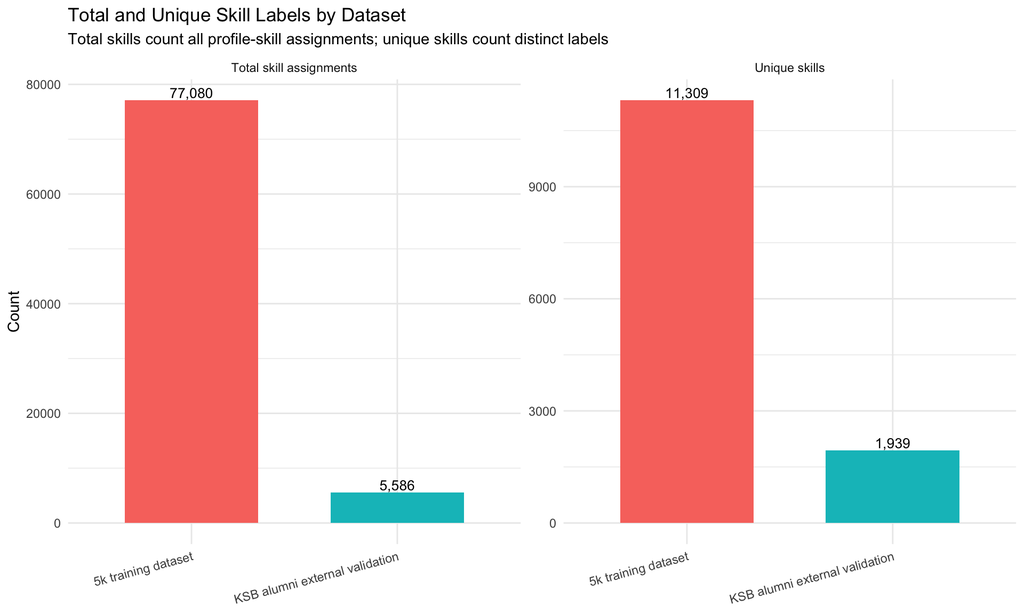

```r
skill_inventory_plot <- skill_inventory |>
  select(dataset, total_number_of_skills, unique_skills) |>
  pivot_longer(
    cols = c(total_number_of_skills, unique_skills),
    names_to = "metric",
    values_to = "count"
  ) |>
  mutate(
    metric = recode(
      metric,
      total_number_of_skills = "Total skill assignments",
      unique_skills = "Unique skills"
    )
  ) |>
  ggplot(aes(x = dataset, y = count, fill = dataset)) +
  geom_col(show.legend = FALSE, width = 0.65) +
  geom_text(aes(label = comma(count)), vjust = -0.25, size = 3.5) +
  facet_wrap(~ metric, scales = "free_y") +
  labs(
    title = "Total and Unique Skill Labels by Dataset",
    subtitle = "Total skills count all profile-skill assignments; unique skills count distinct labels",
    x = NULL,
    y = "Count"
  ) +
  theme_minimal() +
  theme(axis.text.x = element_text(angle = 15, hjust = 1))

skill_inventory_plot
```

```r
ggsave(
  file.path(eda_dir, "skill_inventory_plot.png"),
  skill_inventory_plot,
  width = 10,
  height = 6
)
```

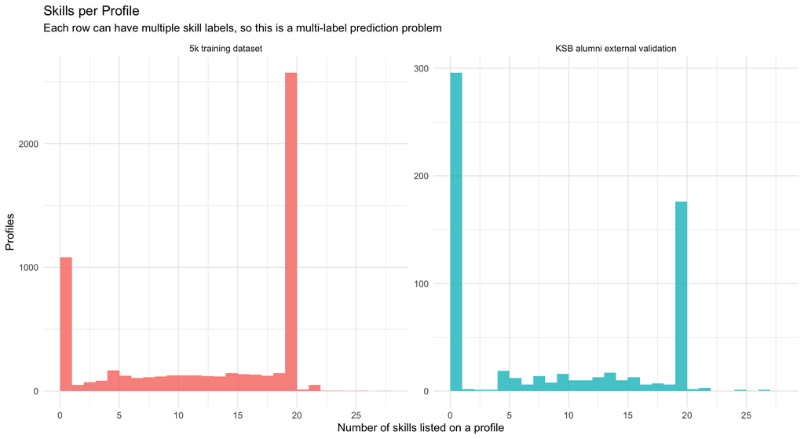

```r
skills_per_profile_plot <- combined_profiles |>
  ggplot(aes(x = skill_count, fill = dataset)) +
  geom_histogram(binwidth = 1, alpha = 0.8, boundary = 0, show.legend = FALSE) +
  facet_wrap(~ dataset, scales = "free_y") +
  scale_x_continuous(breaks = pretty_breaks()) +
  labs(
    title = "Skills per Profile",
    subtitle = "Each row can have multiple skill labels, so this is a multi-label prediction problem",
    x = "Number of skills listed on a profile",
    y = "Profiles"
  ) +
  theme_minimal()

skills_per_profile_plot
```

```r
ggsave(
  file.path(eda_dir, "skills_per_profile_plot.png"),
  skills_per_profile_plot,
  width = 11,
  height = 6
)
```

# Other Important EDA Metrics

These additional metrics connect the dataset summaries back to the modeling problem. A skill extraction model needs enough text signal, enough repeated labels to learn from, and enough overlap between the training label space and the external validation label space.

```r
text_signal_summary <- combined_profiles |>
  group_by(dataset) |>
  summarise(
    profiles = n(),
    profiles_with_profile_text = sum(profile_token_count > 0),
    pct_profiles_with_profile_text = mean(profile_token_count > 0) * 100,
    profiles_with_current_job_description = sum(has_current_job_description == 1),
    pct_profiles_with_current_job_description = mean(has_current_job_description == 1) * 100,
    profiles_with_previous_job_description = sum(has_previous_job_description == 1),
    pct_profiles_with_previous_job_description = mean(has_previous_job_description == 1) * 100,
    total_profile_text_tokens = sum(profile_token_count),
    mean_profile_text_tokens = mean(profile_token_count),
    median_profile_text_tokens = median(profile_token_count),
    .groups = "drop"
  )

text_signal_summary
```

```
## # A tibble: 2 × 11
##   dataset                 profiles profiles_with_profil…¹ pct_profiles_with_pr…²
##   <chr>                      <int>                  <int>                  <dbl>
## 1 5k training dataset         5865                   5704                   97.3
## 2 KSB alumni external va…      650                    650                  100
## # ℹ abbreviated names: ¹profiles_with_profile_text,
## #   ²pct_profiles_with_profile_text
## # ℹ 7 more variables: profiles_with_current_job_description <int>,
## #   pct_profiles_with_current_job_description <dbl>,
## #   profiles_with_previous_job_description <int>,
## #   pct_profiles_with_previous_job_description <dbl>,
## #   total_profile_text_tokens <int>, mean_profile_text_tokens <dbl>, …
```

```r
write_csv(text_signal_summary, file.path(eda_dir, "text_signal_summary.csv"))
```

```r
top_20_skill_names <- skills_long |>
  group_by(dataset) |>
  count(skill, sort = TRUE) |>
  slice_max(order_by = n, n = 20, with_ties = FALSE) |>
  ungroup()

top_20_skill_assignments <- skills_long |>
  semi_join(top_20_skill_names, by = c("dataset", "skill")) |>
  count(dataset, name = "assignments_in_top_20_skills")

label_density_summary <- skill_inventory |>
  left_join(top_20_skill_assignments, by = "dataset") |>
  mutate(
    possible_profile_skill_pairs = profiles_with_skills * unique_skills,
    label_density_pct = total_number_of_skills / possible_profile_skill_pairs * 100,
    pct_assignments_in_top_20_skills = assignments_in_top_20_skills / total_number_of_skills * 100
  ) |>
  select(
    dataset,
    total_number_of_skills,
    unique_skills,
    possible_profile_skill_pairs,
    label_density_pct,
    assignments_in_top_20_skills,
    pct_assignments_in_top_20_skills
  )

label_density_summary
```

```
## # A tibble: 2 × 7
##   dataset            total_number_of_skills unique_skills possible_profile_ski…¹
##   <chr>                               <int>         <int>                  <int>
## 1 5k training datas…                  77080         11309               54701633
## 2 KSB alumni extern…                   5586          1939                 696101
## # ℹ abbreviated name: ¹possible_profile_skill_pairs
## # ℹ 3 more variables: label_density_pct <dbl>,
## #   assignments_in_top_20_skills <int>, pct_assignments_in_top_20_skills <dbl>
```

```r
write_csv(label_density_summary, file.path(eda_dir, "label_density_summary.csv"))
```

```r
training_skills <- skills_long |>
  filter(dataset == "5k training dataset") |>
  distinct(skill) |>
  pull(skill)

external_skills <- skills_long |>
  filter(dataset == "KSB alumni external validation") |>
  distinct(skill) |>
  pull(skill)

skill_overlap_summary <- tibble(
  training_unique_skills = length(training_skills),
  external_unique_skills = length(external_skills),
  shared_unique_skills = length(intersect(training_skills, external_skills)),
  external_unique_skills_seen_in_training = sum(external_skills %in% training_skills),
  external_unique_skills_unseen_in_training = sum(!external_skills %in% training_skills),
  pct_external_unique_skills_seen_in_training = mean(external_skills %in% training_skills) * 100
)

skill_overlap_summary
```

```
## # A tibble: 1 × 6
##   training_unique_skills external_unique_skills shared_unique_skills
##                    <int>                  <int>                <int>
## 1                  11309                   1939                 1425
## # ℹ 3 more variables: external_unique_skills_seen_in_training <int>,
## #   external_unique_skills_unseen_in_training <int>,
## #   pct_external_unique_skills_seen_in_training <dbl>
```

```r
write_csv(skill_overlap_summary, file.path(eda_dir, "skill_overlap_summary.csv"))
```

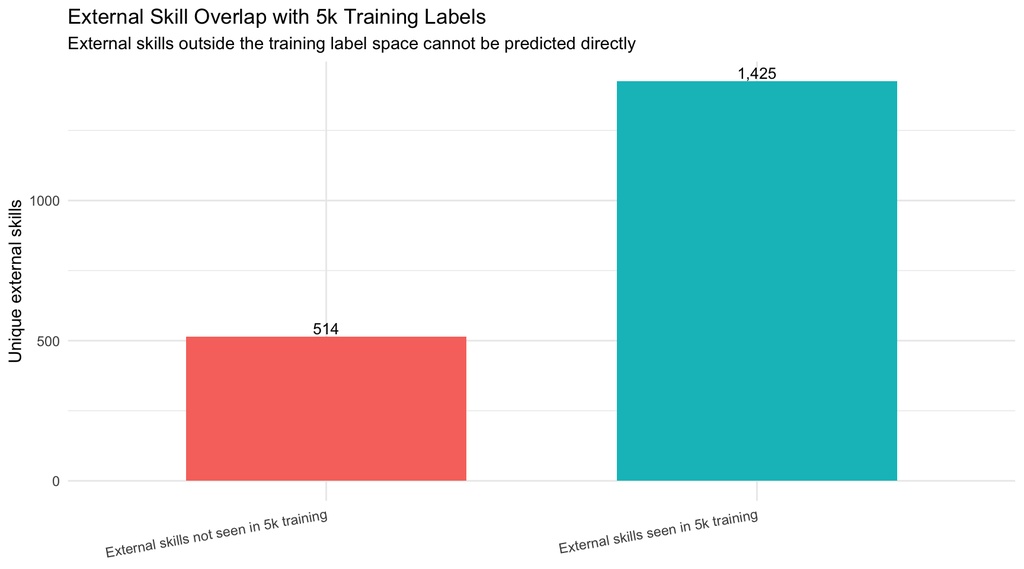

```r
skill_overlap_plot_data <- tibble(
  overlap_group = c("External skills seen in 5k training", "External skills not seen in 5k training"),
  unique_skills = c(
    skill_overlap_summary$external_unique_skills_seen_in_training,
    skill_overlap_summary$external_unique_skills_unseen_in_training
  )
)

skill_overlap_plot <- skill_overlap_plot_data |>
  ggplot(aes(x = overlap_group, y = unique_skills, fill = overlap_group)) +
  geom_col(show.legend = FALSE, width = 0.65) +
  geom_text(aes(label = comma(unique_skills)), vjust = -0.25, size = 3.5) +
  labs(
    title = "External Skill Overlap with 5k Training Labels",
    subtitle = "External skills outside the training label space cannot be predicted directly",
    x = NULL,
    y = "Unique external skills"
  ) +
  theme_minimal() +
  theme(axis.text.x = element_text(angle = 10, hjust = 1))

skill_overlap_plot
```

```r
ggsave(
  file.path(eda_dir, "skill_overlap_plot.png"),
  skill_overlap_plot,
  width = 9,
  height = 5
)
```

```r
external_model_metrics_path <- file.path(
  processed_dir,
  "external_validation_model_outputs",
  "external_validation_all_model_results.rds"
)

if (file.exists(external_model_metrics_path)) {
  external_model_results <- readRDS(external_model_metrics_path)
  modeled_skills <- external_model_results$retained_skills
} else {
  split_objects <- readRDS(file.path(processed_dir, "train_validation_test_split.rds"))
  y_train <- as.matrix(split_objects$y_train)
  label_order <- order(colMeans(y_train), decreasing = TRUE)
  modeled_skills <- colnames(y_train)[label_order[seq_len(min(100, ncol(y_train)))]]
}

modeled_skill_readiness_summary <- skills_long |>
  filter(dataset == "KSB alumni external validation") |>
  mutate(in_modeled_skill_space = skill %in% modeled_skills) |>
  summarise(
    modeled_skill_count = length(modeled_skills),
    external_skill_assignments = n(),
    external_assignments_in_modeled_skill_space = sum(in_modeled_skill_space),
    pct_external_assignments_in_modeled_skill_space = mean(in_modeled_skill_space) * 100,
    external_unique_skills = n_distinct(skill),
    external_unique_skills_in_modeled_skill_space = n_distinct(skill[in_modeled_skill_space]),
    pct_external_unique_skills_in_modeled_skill_space =
      external_unique_skills_in_modeled_skill_space / external_unique_skills * 100
  )

modeled_skill_readiness_summary
```

```
## # A tibble: 1 × 7
##   modeled_skill_count external_skill_assignments external_assignments_in_model…¹
##                 <int>                      <int>                           <int>
## 1                 100                       5586                            2509
## # ℹ abbreviated name: ¹external_assignments_in_modeled_skill_space
## # ℹ 4 more variables: pct_external_assignments_in_modeled_skill_space <dbl>,
## #   external_unique_skills <int>,
## #   external_unique_skills_in_modeled_skill_space <int>,
## #   pct_external_unique_skills_in_modeled_skill_space <dbl>
```

```r
write_csv(
  modeled_skill_readiness_summary,
  file.path(eda_dir, "modeled_skill_readiness_summary.csv")
)
```

# Dataset Readiness for Skill Extraction

```r
dataset_summary <- make_dataset_summary(combined_profiles)
dataset_summary
```

```
## # A tibble: 2 × 11
##   dataset                   profiles profiles_with_skills pct_profiles_with_sk…¹
##   <chr>                        <int>                <int>                  <dbl>
## 1 5k training dataset           5865                 4837                   82.5
## 2 KSB alumni external vali…      650                  359                   55.2
## # ℹ abbreviated name: ¹pct_profiles_with_skills
## # ℹ 7 more variables: avg_skills_per_profile <dbl>,
## #   median_skills_per_profile <dbl>, avg_profile_tokens <dbl>,
## #   median_profile_tokens <dbl>, pct_profiles_with_current_description <dbl>,
## #   pct_profiles_with_previous_description <dbl>, avg_experience_count <dbl>
```

```r
write_csv(dataset_summary, file.path(eda_dir, "dataset_readiness_summary.csv"))
```

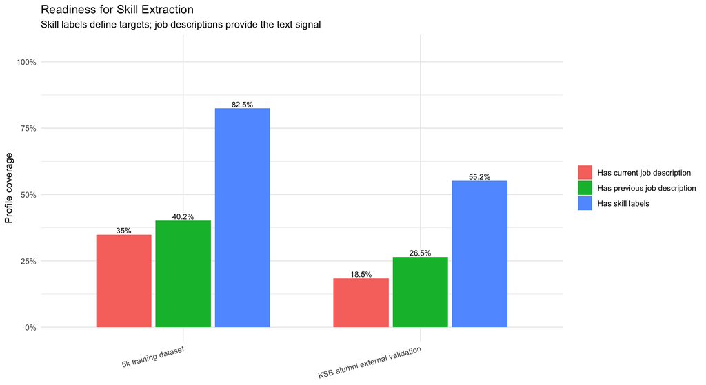

```r
readiness_long <- dataset_summary |>
  select(
    dataset,
    pct_profiles_with_skills,
    pct_profiles_with_current_description,
    pct_profiles_with_previous_description
  ) |>
  pivot_longer(
    cols = -dataset,
    names_to = "metric",
    values_to = "percent"
  ) |>
  mutate(
    metric = recode(
      metric,
      pct_profiles_with_skills = "Has skill labels",
      pct_profiles_with_current_description = "Has current job description",
      pct_profiles_with_previous_description = "Has previous job description"
    )
  )

coverage_plot <- readiness_long |>
  ggplot(aes(x = dataset, y = percent, fill = metric)) +
  geom_col(position = position_dodge(width = 0.75), width = 0.7) +
  geom_text(
    aes(label = paste0(round(percent, 1), "%")),
    position = position_dodge(width = 0.75),
    vjust = -0.25,
    size = 3
  ) +
  scale_y_continuous(labels = label_percent(scale = 1), limits = c(0, 105)) +
  labs(
    title = "Readiness for Skill Extraction",
    subtitle = "Skill labels define targets; job descriptions provide the text signal",
    x = NULL,
    y = "Profile coverage",
    fill = NULL
  ) +
  theme_minimal() +
  theme(axis.text.x = element_text(angle = 15, hjust = 1))

coverage_plot
```

```r
ggsave(
  file.path(eda_dir, "readiness_coverage_plot.png"),
  coverage_plot,
  width = 11,
  height = 6
)
```

# Text Signal: How Much Job Description Text Exists?

```r
token_summary <- combined_profiles |>
  group_by(dataset) |>
  summarise(
    min_tokens = min(profile_token_count),
    p25_tokens = quantile(profile_token_count, 0.25),
    median_tokens = median(profile_token_count),
    mean_tokens = mean(profile_token_count),
    p75_tokens = quantile(profile_token_count, 0.75),
    max_tokens = max(profile_token_count),
    .groups = "drop"
  )

token_summary
```

```
## # A tibble: 2 × 7
##   dataset  min_tokens p25_tokens median_tokens mean_tokens p75_tokens max_tokens
##   <chr>         <int>      <dbl>         <dbl>       <dbl>      <dbl>      <int>
## 1 5k trai…          0         11            23        61.0       83          565
## 2 KSB alu…          1          2             9        47.4       33.8        554
```

```r
write_csv(token_summary, file.path(eda_dir, "profile_text_token_summary.csv"))
```

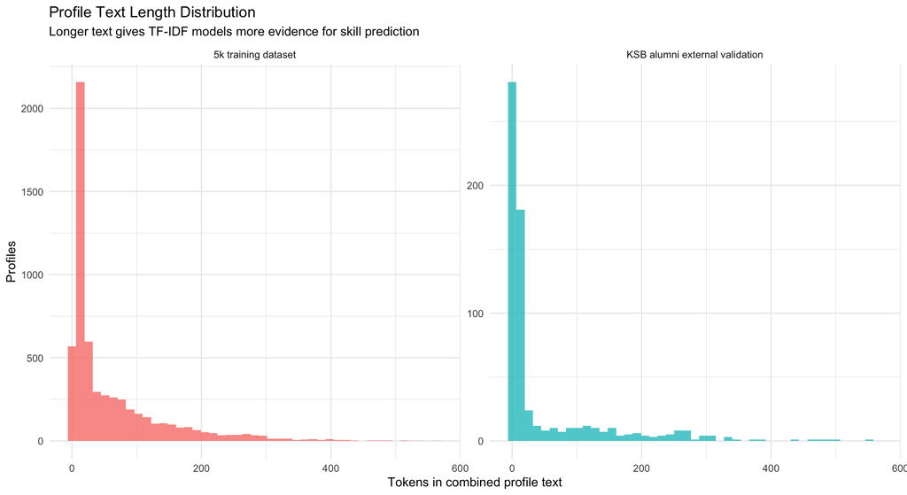

```r
token_plot <- combined_profiles |>
  ggplot(aes(x = profile_token_count, fill = dataset)) +
  geom_histogram(bins = 45, alpha = 0.75, show.legend = FALSE) +
  facet_wrap(~ dataset, scales = "free_y") +
  labs(
    title = "Profile Text Length Distribution",
    subtitle = "Longer text gives TF-IDF models more evidence for skill prediction",
    x = "Tokens in combined profile text",
    y = "Profiles"
  ) +
  theme_minimal()

token_plot
```

```r
ggsave(
  file.path(eda_dir, "profile_text_token_distribution.png"),
  token_plot,
  width = 11,
  height = 6
)
```

# Skill Label Coverage and Imbalance

```r
skill_coverage <- skill_inventory |>
  rename(total_skill_assignments = total_number_of_skills)

skill_coverage
```

```
## # A tibble: 2 × 5
##   dataset              total_skill_assignme…¹ unique_skills profiles_with_skills
##   <chr>                                 <int>         <int>                <int>
## 1 5k training dataset                   77080         11309                 4837
## 2 KSB alumni external…                   5586          1939                  359
## # ℹ abbreviated name: ¹total_skill_assignments
## # ℹ 1 more variable: avg_profiles_per_skill <dbl>
```

```r
write_csv(skill_coverage, file.path(eda_dir, "skill_coverage_summary.csv"))
```

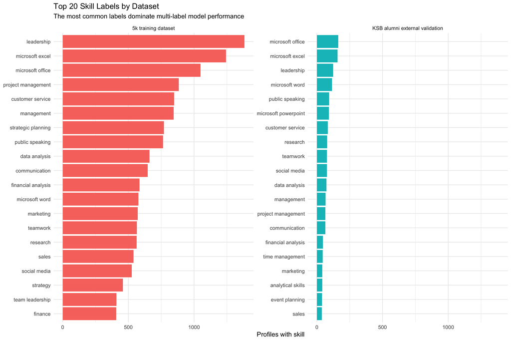

```r
top_skills <- skills_long |>
  count(dataset, skill, sort = TRUE) |>
  group_by(dataset) |>
  slice_max(order_by = n, n = 20, with_ties = FALSE) |>
  ungroup()

top_skills_plot <- top_skills |>
  mutate(skill = reorder_within(skill, n, dataset)) |>
  ggplot(aes(x = skill, y = n, fill = dataset)) +
  geom_col(show.legend = FALSE) +
  coord_flip() +
  facet_wrap(~ dataset, scales = "free_y") +
  scale_x_reordered() +
  labs(
    title = "Top 20 Skill Labels by Dataset",
    subtitle = "The most common labels dominate multi-label model performance",
    x = NULL,
    y = "Profiles with skill"
  ) +
  theme_minimal()

top_skills_plot
```

```r
write_csv(top_skills, file.path(eda_dir, "top_20_skills_by_dataset.csv"))
ggsave(
  file.path(eda_dir, "top_20_skills_by_dataset.png"),
  top_skills_plot,
  width = 12,
  height = 8
)
```

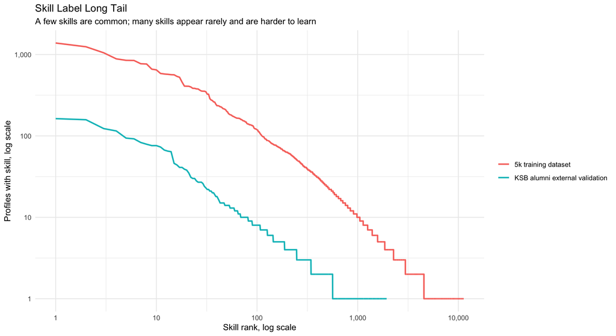

```r
skill_frequency_rank <- skills_long |>
  count(dataset, skill, sort = TRUE) |>
  group_by(dataset) |>
  arrange(desc(n), .by_group = TRUE) |>
  mutate(skill_rank = row_number()) |>
  ungroup()

long_tail_plot <- skill_frequency_rank |>
  ggplot(aes(x = skill_rank, y = n, color = dataset)) +
  geom_line(linewidth = 0.9) +
  scale_x_log10(labels = comma) +
  scale_y_log10(labels = comma) +
  labs(
    title = "Skill Label Long Tail",
    subtitle = "A few skills are common; many skills appear rarely and are harder to learn",
    x = "Skill rank, log scale",
    y = "Profiles with skill, log scale",
    color = NULL
  ) +
  theme_minimal()

long_tail_plot
```

```r
ggsave(
  file.path(eda_dir, "skill_label_long_tail.png"),
  long_tail_plot,
  width = 11,
  height = 6
)
```

# Text Terms Most Available for Modeling

```r
top_terms <- combined_profiles |>
  select(dataset, profile_id, profile_text) |>
  unnest_tokens(term, profile_text) |>
  anti_join(stop_words, by = c("term" = "word")) |>
  filter(str_detect(term, "[a-z]"), nchar(term) > 2) |>
  count(dataset, term, sort = TRUE) |>
  group_by(dataset) |>
  slice_max(order_by = n, n = 20, with_ties = FALSE) |>
  ungroup()

top_terms
```

```
## # A tibble: 40 × 3
##    dataset             term            n
##    <chr>               <chr>       <int>
##  1 5k training dataset business     2899
##  2 5k training dataset management   2438
##  3 5k training dataset manager      2135
##  4 5k training dataset director     1851
##  5 5k training dataset marketing    1714
##  6 5k training dataset development  1439
##  7 5k training dataset financial    1424
##  8 5k training dataset data         1419
##  9 5k training dataset operations   1371
## 10 5k training dataset senior       1336
## # ℹ 30 more rows
```

```r
write_csv(top_terms, file.path(eda_dir, "top_profile_text_terms.csv"))
```

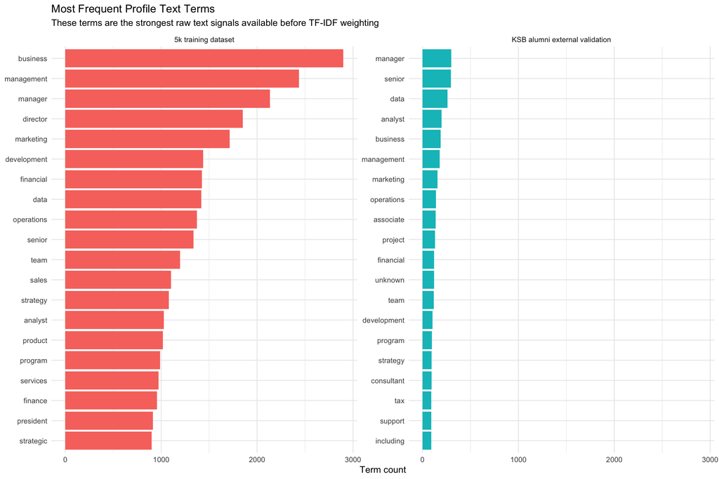

```r
top_terms_plot <- top_terms |>
  mutate(term = reorder_within(term, n, dataset)) |>
  ggplot(aes(x = term, y = n, fill = dataset)) +
  geom_col(show.legend = FALSE) +
  coord_flip() +
  facet_wrap(~ dataset, scales = "free_y") +
  scale_x_reordered() +
  labs(
    title = "Most Frequent Profile Text Terms",
    subtitle = "These terms are the strongest raw text signals available before TF-IDF weighting",
    x = NULL,
    y = "Term count"
  ) +
  theme_minimal()

top_terms_plot
```

```r
ggsave(
  file.path(eda_dir, "top_profile_text_terms.png"),
  top_terms_plot,
  width = 12,
  height = 8
)
```

# Do Skill Labels Appear in Job Description Text?

```r
# This checks whether the skill label itself appears in the profile text. The
# model can still learn implicit signals, but explicit mentions are easier.
skill_mentions <- skills_long |>
  left_join(
    combined_profiles |> select(dataset, profile_id, profile_text),
    by = c("dataset", "profile_id")
  ) |>
  mutate(skill_explicitly_mentioned = str_detect(profile_text, fixed(skill))) |>
  group_by(dataset) |>
  summarise(
    skill_assignments = n(),
    explicit_skill_mentions = sum(skill_explicitly_mentioned, na.rm = TRUE),
    pct_explicit_mentions = explicit_skill_mentions / skill_assignments * 100,
    .groups = "drop"
  )

skill_mentions
```

```
## # A tibble: 2 × 4
##   dataset         skill_assignments explicit_skill_menti…¹ pct_explicit_mentions
##   <chr>                       <int>                  <int>                 <dbl>
## 1 5k training da…             77080                   5029                  6.52
## 2 KSB alumni ext…              5586                    246                  4.40
## # ℹ abbreviated name: ¹explicit_skill_mentions
```

```r
write_csv(skill_mentions, file.path(eda_dir, "explicit_skill_mentions_summary.csv"))
```

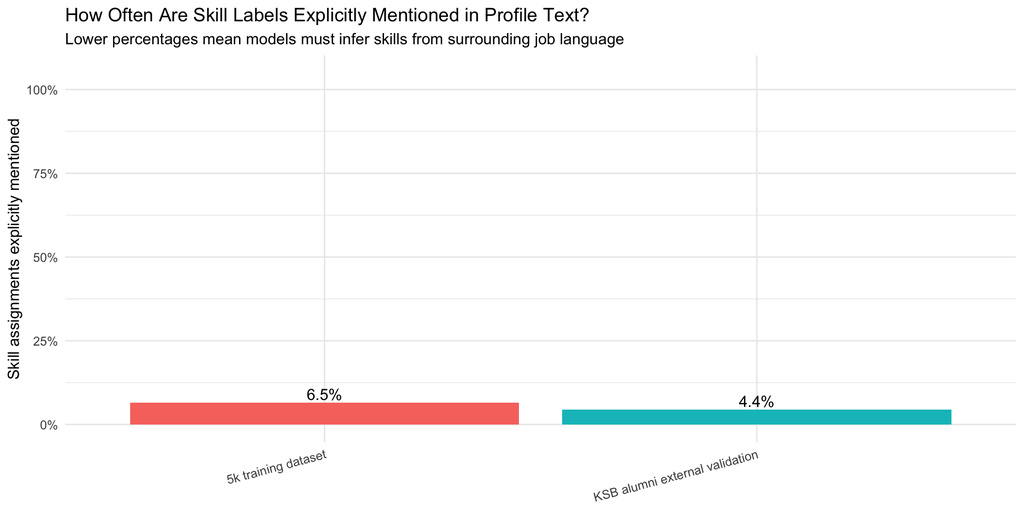

```r
skill_mentions_plot <- skill_mentions |>
  ggplot(aes(x = dataset, y = pct_explicit_mentions, fill = dataset)) +
  geom_col(show.legend = FALSE) +
  geom_text(aes(label = paste0(round(pct_explicit_mentions, 1), "%")), vjust = -0.25) +
  scale_y_continuous(labels = label_percent(scale = 1), limits = c(0, 105)) +
  labs(
    title = "How Often Are Skill Labels Explicitly Mentioned in Profile Text?",
    subtitle = "Lower percentages mean models must infer skills from surrounding job language",
    x = NULL,
    y = "Skill assignments explicitly mentioned"
  ) +
  theme_minimal() +
  theme(axis.text.x = element_text(angle = 15, hjust = 1))

skill_mentions_plot
```

```r
ggsave(
  file.path(eda_dir, "explicit_skill_mentions_plot.png"),
  skill_mentions_plot,
  width = 10,
  height = 5
)
```

# External Validation Drift

```r
training_skills <- skills_long |>
  filter(dataset == "5k training dataset") |>
  distinct(skill) |>
  pull(skill)

external_skills <- skills_long |>
  filter(dataset == "KSB alumni external validation") |>
  distinct(skill) |>
  pull(skill)

external_overlap <- tibble(
  external_unique_skills = length(external_skills),
  external_skills_seen_in_training = sum(external_skills %in% training_skills),
  external_skills_unseen_in_training = sum(!external_skills %in% training_skills),
  pct_external_skills_seen_in_training = mean(external_skills %in% training_skills) * 100
)

external_overlap
```

```
## # A tibble: 1 × 4
##   external_unique_skills external_skills_seen_in_training external_skills_unse…¹
##                    <int>                            <int>                  <int>
## 1                   1939                             1425                    514
## # ℹ abbreviated name: ¹external_skills_unseen_in_training
## # ℹ 1 more variable: pct_external_skills_seen_in_training <dbl>
```

```r
write_csv(external_overlap, file.path(eda_dir, "external_skill_overlap_with_training.csv"))
```

```r
# The current external validation modeling file evaluates the 100 modeled labels.
# This table shows how many of the external validation skill assignments fall
# inside that model label space.
external_model_metrics_path <- file.path(
  processed_dir,
  "external_validation_model_outputs",
  "external_validation_all_model_results.rds"
)

if (file.exists(external_model_metrics_path)) {
  external_model_results <- readRDS(external_model_metrics_path)
  modeled_skills <- external_model_results$retained_skills
} else {
  split_objects <- readRDS(file.path(processed_dir, "train_validation_test_split.rds"))
  y_train <- as.matrix(split_objects$y_train)
  label_order <- order(colMeans(y_train), decreasing = TRUE)
  modeled_skills <- colnames(y_train)[label_order[seq_len(min(100, ncol(y_train)))]]
}

modeled_skill_coverage <- skills_long |>
  filter(dataset == "KSB alumni external validation") |>
  mutate(in_modeled_skill_space = skill %in% modeled_skills) |>
  summarise(
    external_skill_assignments = n(),
    assignments_in_100_skill_model_space = sum(in_modeled_skill_space),
    pct_assignments_in_100_skill_model_space = mean(in_modeled_skill_space) * 100,
    unique_external_skills = n_distinct(skill),
    unique_external_skills_in_100_skill_model_space = n_distinct(skill[in_modeled_skill_space])
  )

modeled_skill_coverage
```

```
## # A tibble: 1 × 5
##   external_skill_assignments assignments_in_100_skill_m…¹ pct_assignments_in_1…²
##                        <int>                        <int>                  <dbl>
## 1                       5586                         2509                   44.9
## # ℹ abbreviated names: ¹assignments_in_100_skill_model_space,
## #   ²pct_assignments_in_100_skill_model_space
## # ℹ 2 more variables: unique_external_skills <int>,
## #   unique_external_skills_in_100_skill_model_space <int>
```

```r
write_csv(modeled_skill_coverage, file.path(eda_dir, "external_modeled_skill_coverage.csv"))
```

# Relationship Between Text Length and Skill Labels

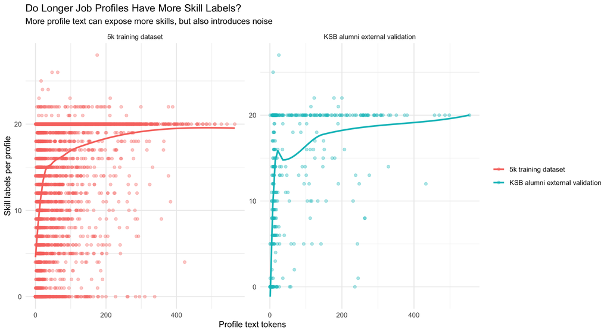

```r
text_skill_plot <- combined_profiles |>
  ggplot(aes(x = profile_token_count, y = skill_count, color = dataset)) +
  geom_point(alpha = 0.35) +
  geom_smooth(method = "loess", se = FALSE) +
  facet_wrap(~ dataset, scales = "free") +
  labs(
    title = "Do Longer Job Profiles Have More Skill Labels?",
    subtitle = "More profile text can expose more skills, but also introduces noise",
    x = "Profile text tokens",
    y = "Skill labels per profile",
    color = NULL
  ) +
  theme_minimal()

text_skill_plot
```

```r
ggsave(
  file.path(eda_dir, "text_length_vs_skill_count.png"),
  text_skill_plot,
  width = 11,
  height = 6
)
```

# Model-Aware EDA: TF-IDF Vocabulary and Sparsity

**Non-technical explanation.** This section checks whether the profile text has enough repeated language for a model to learn from. A model cannot learn well if nearly every word appears only once, or if most profiles share very few terms.

**Technical explanation.** Logistic Regression, KNN, and XGBoost use the TF-IDF feature space created from `profile_text`. Text models usually create a very sparse document-term matrix: most profiles contain only a small fraction of all vocabulary terms. This is normal, but extreme sparsity can weaken KNN distance calculations and make rare-term patterns harder for tree-based models to learn.

```r
profile_terms <- combined_profiles |>
  select(dataset, profile_id, profile_text) |>
  unnest_tokens(term, profile_text) |>
  anti_join(stop_words, by = c("term" = "word")) |>
  filter(str_detect(term, "[a-z]"), nchar(term) > 2)

profile_term_counts <- profile_terms |>
  count(dataset, profile_id, term, name = "term_count")

vocabulary_summary <- profile_term_counts |>
  group_by(dataset) |>
  summarise(
    profiles = n_distinct(profile_id),
    vocabulary_size = n_distinct(term),
    observed_profile_term_pairs = n(),
    possible_profile_term_pairs = profiles * vocabulary_size,
    tfidf_space_sparsity_pct =
      (1 - observed_profile_term_pairs / possible_profile_term_pairs) * 100,
    avg_unique_terms_per_profile = observed_profile_term_pairs / profiles,
    .groups = "drop"
  )

vocabulary_summary
```

```
## # A tibble: 2 × 7
##   dataset profiles vocabulary_size observed_profile_ter…¹ possible_profile_ter…²
##   <chr>      <int>           <int>                  <int>                  <int>
## 1 5k tra…     5703           17668                 192201              100760604
## 2 KSB al…      649            4320                  15858                2803680
## # ℹ abbreviated names: ¹observed_profile_term_pairs,
## #   ²possible_profile_term_pairs
## # ℹ 2 more variables: tfidf_space_sparsity_pct <dbl>,
## #   avg_unique_terms_per_profile <dbl>
```

```r
write_csv(
  vocabulary_summary,
  file.path(eda_dir, "tfidf_vocabulary_sparsity_summary.csv")
)
```

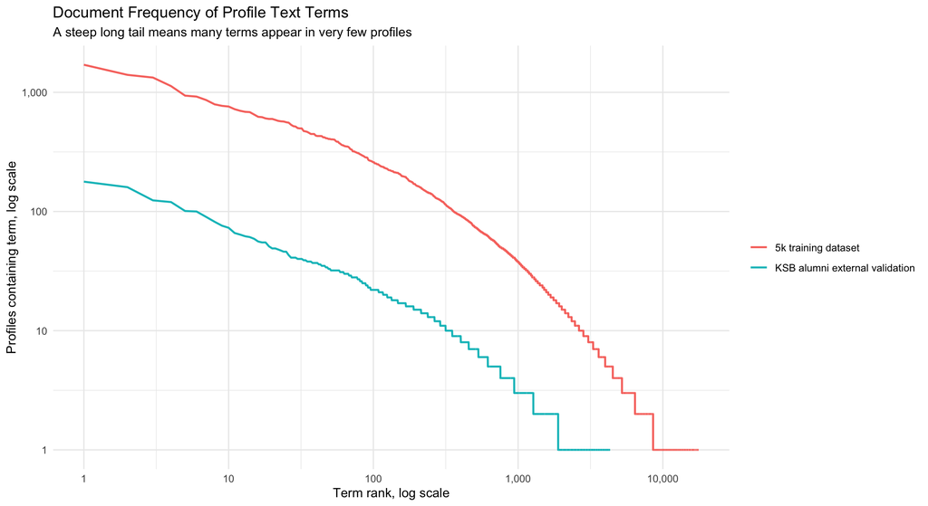

```r
term_document_frequency <- profile_term_counts |>
  count(dataset, term, name = "document_frequency") |>
  group_by(dataset) |>
  mutate(term_rank = row_number(desc(document_frequency))) |>
  ungroup()

term_document_frequency_plot <- term_document_frequency |>
  ggplot(aes(x = term_rank, y = document_frequency, color = dataset)) +
  geom_line(linewidth = 0.8) +
  scale_x_log10(labels = comma) +
  scale_y_log10(labels = comma) +
  labs(
    title = "Document Frequency of Profile Text Terms",
    subtitle = "A steep long tail means many terms appear in very few profiles",
    x = "Term rank, log scale",
    y = "Profiles containing term, log scale",
    color = NULL
  ) +
  theme_minimal()

term_document_frequency_plot
```

```r
ggsave(
  file.path(eda_dir, "term_document_frequency_long_tail.png"),
  term_document_frequency_plot,
  width = 11,
  height = 6
)
```

**Interpretation for modeling.** High sparsity is expected in NLP, but it means KNN may struggle because most profiles are far apart in the feature space. Logistic Regression is usually more stable for sparse TF-IDF features. XGBoost may still perform well, but it needs careful threshold tuning because it can learn common-skill patterns more easily than rare-skill patterns.

# Profiles with No Skill Labels

**Non-technical explanation.** Profiles with no skill labels are not useless. They teach the model what a profile with no observable modeled skills looks like. Removing them can make the model too aggressive and cause it to predict skills too often.

**Technical explanation.** In a multi-label target matrix, profiles with zero skills become all-zero target rows. These rows are important negative examples. Removing them changes the base rate of positive labels, inflates label density, and can bias precision/recall estimates.

```r
zero_skill_profile_summary <- combined_profiles |>
  mutate(has_any_skill = skill_count > 0) |>
  group_by(dataset, has_any_skill) |>
  summarise(
    profiles = n(),
    mean_profile_tokens = mean(profile_token_count),
    median_profile_tokens = median(profile_token_count),
    pct_with_current_job_description = mean(has_current_job_description == 1) * 100,
    pct_with_previous_job_description = mean(has_previous_job_description == 1) * 100,
    .groups = "drop"
  ) |>
  mutate(skill_label_status = if_else(has_any_skill, "Has at least one skill", "Has zero skills")) |>
  select(dataset, skill_label_status, everything(), -has_any_skill)

zero_skill_profile_summary
```

```
## # A tibble: 4 × 7
##   dataset  skill_label_status profiles mean_profile_tokens median_profile_tokens
##   <chr>    <chr>                 <int>               <dbl>                 <dbl>
## 1 5k trai… Has zero skills        1028               17.7                      9
## 2 5k trai… Has at least one …     4837               70.1                     33
## 3 KSB alu… Has zero skills         291                4.06                     2
## 4 KSB alu… Has at least one …      359               82.4                     20
## # ℹ 2 more variables: pct_with_current_job_description <dbl>,
## #   pct_with_previous_job_description <dbl>
```

```r
write_csv(
  zero_skill_profile_summary,
  file.path(eda_dir, "zero_skill_profile_diagnostics.csv")
)
```

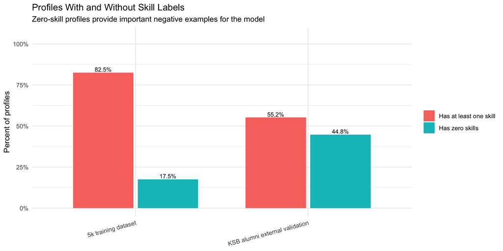

```r
zero_skill_profile_plot <- combined_profiles |>
  mutate(skill_label_status = if_else(skill_count > 0, "Has at least one skill", "Has zero skills")) |>
  count(dataset, skill_label_status) |>
  group_by(dataset) |>
  mutate(percent = n / sum(n) * 100) |>
  ungroup() |>
  ggplot(aes(x = dataset, y = percent, fill = skill_label_status)) +
  geom_col(position = position_dodge(width = 0.75), width = 0.7) +
  geom_text(
    aes(label = paste0(round(percent, 1), "%")),
    position = position_dodge(width = 0.75),
    vjust = -0.25,
    size = 3
  ) +
  scale_y_continuous(labels = label_percent(scale = 1), limits = c(0, 105)) +
  labs(
    title = "Profiles With and Without Skill Labels",
    subtitle = "Zero-skill profiles provide important negative examples for the model",
    x = NULL,
    y = "Percent of profiles",
    fill = NULL
  ) +
  theme_minimal() +
  theme(axis.text.x = element_text(angle = 15, hjust = 1))

zero_skill_profile_plot
```

```r
ggsave(
  file.path(eda_dir, "zero_skill_profile_plot.png"),
  zero_skill_profile_plot,
  width = 10,
  height = 5
)
```

# Text-to-Skill Signal Strength

**Non-technical explanation.** This section checks whether certain words in the profile text are meaningfully connected to specific skills. For example, if profiles labeled with `python` also contain words like `data`, `analysis`, `automation`, or `machine`, that gives the model a real signal.

**Technical explanation.** The table below estimates token-skill association using a simple lift ratio. Lift compares how often a term appears among profiles with a given skill versus how often it appears overall. A lift greater than 1 means the term is more common among profiles with that skill than in the full dataset.

```r
# Focus on modeled skills so the signal check matches the downstream model label space.
modeled_skills_available <- modeled_skills[modeled_skills %in% training_skills]
selected_signal_skills <- modeled_skills_available[seq_len(min(15, length(modeled_skills_available)))]

training_profiles <- combined_profiles |>
  filter(dataset == "5k training dataset") |>
  select(dataset, profile_id, profile_text)

training_profile_terms <- training_profiles |>
  unnest_tokens(term, profile_text) |>
  anti_join(stop_words, by = c("term" = "word")) |>
  filter(str_detect(term, "[a-z]"), nchar(term) > 2) |>
  distinct(profile_id, term)

training_skill_profile_map <- skills_long |>
  filter(dataset == "5k training dataset", skill %in% selected_signal_skills) |>
  distinct(profile_id, skill)

training_profile_count <- n_distinct(training_profiles$profile_id)

term_base_rates <- training_profile_terms |>
  count(term, name = "profiles_with_term") |>
  mutate(base_rate = profiles_with_term / training_profile_count)

skill_profile_counts <- training_skill_profile_map |>
  count(skill, name = "profiles_with_skill")

token_skill_association <- training_skill_profile_map |>
  inner_join(training_profile_terms, by = "profile_id") |>
  count(skill, term, name = "profiles_with_skill_and_term") |>
  left_join(skill_profile_counts, by = "skill") |>
  left_join(term_base_rates, by = "term") |>
  mutate(
    term_rate_within_skill = profiles_with_skill_and_term / profiles_with_skill,
    lift = term_rate_within_skill / base_rate
  ) |>
  filter(profiles_with_skill_and_term >= 3, profiles_with_term >= 5) |>
  group_by(skill) |>
  slice_max(order_by = lift, n = 8, with_ties = FALSE) |>
  arrange(skill, desc(lift)) |>
  ungroup()

token_skill_association
```

```
## # A tibble: 120 × 8
##    skill     term  profiles_with_skill_…¹ profiles_with_skill profiles_with_term
##    <chr>     <chr>                  <int>               <int>              <int>
##  1 communic… inte…                      5                 647                  7
##  2 communic… risi…                      4                 647                  6
##  3 communic… alum…                      3                 647                  5
##  4 communic… appe…                      3                 647                  5
##  5 communic… atti…                      3                 647                  5
##  6 communic… bent…                      3                 647                  5
##  7 communic… diso…                      3                 647                  5
##  8 communic… land…                      3                 647                  5
##  9 customer… save                       5                 848                  6
## 10 customer… tour…                      4                 848                  5
## # ℹ 110 more rows
## # ℹ abbreviated name: ¹profiles_with_skill_and_term
## # ℹ 3 more variables: base_rate <dbl>, term_rate_within_skill <dbl>, lift <dbl>
```

```r
write_csv(
  token_skill_association,
  file.path(eda_dir, "token_skill_association_lift.csv")
)
```

```r
if (nrow(token_skill_association) > 0) {
  token_skill_association_plot <- token_skill_association |>
    mutate(term = reorder_within(term, lift, skill)) |>
    ggplot(aes(x = term, y = lift, fill = skill)) +
    geom_col(show.legend = FALSE) +
    coord_flip() +
    facet_wrap(~ skill, scales = "free_y") +
    scale_x_reordered() +
    labs(
      title = "Strongest Text Terms Associated with Selected Skills",
      subtitle = "Lift greater than 1 means the term is more common among profiles with that skill",
      x = NULL,
      y = "Association lift"
    ) +
    theme_minimal()

  token_skill_association_plot

  ggsave(
    file.path(eda_dir, "token_skill_association_lift.png"),
    token_skill_association_plot,
    width = 13,
    height = 9
  )
}
```

**Interpretation for modeling.** If the lift table contains intuitive terms for major skills, that supports the use of TF-IDF models. If the terms look generic or unrelated, then the model may be learning broad profile style rather than actual skill evidence.

# Multi-Label Skill Co-Occurrence

**Non-technical explanation.** Skills often appear together. A profile with `data analysis` may also list `excel`, `sql`, or `python`. Understanding these combinations helps explain why the task is multi-label rather than single-label.

**Technical explanation.** This section identifies frequent skill pairs within the same profile. Co-occurrence can support interpretation and model diagnostics, although the current one-vs-rest model setup predicts each skill independently.

```r
cooccurrence_skills <- skills_long |>
  filter(dataset == "5k training dataset", skill %in% modeled_skills) |>
  distinct(profile_id, skill)

skill_pairs <- cooccurrence_skills |>
  inner_join(cooccurrence_skills, by = "profile_id", suffix = c("_1", "_2")) |>
  filter(skill_1 < skill_2) |>
  count(skill_1, skill_2, name = "profiles_with_both") |>
  arrange(desc(profiles_with_both))

top_skill_pairs <- skill_pairs |>
  slice_max(order_by = profiles_with_both, n = 25, with_ties = FALSE)

top_skill_pairs
```

```
## # A tibble: 25 × 3
##    skill_1          skill_2          profiles_with_both
##    <chr>            <chr>                         <int>
##  1 microsoft excel  microsoft office                654
##  2 leadership       microsoft excel                 526
##  3 microsoft excel  microsoft word                  500
##  4 leadership       microsoft office                468
##  5 leadership       management                      466
##  6 leadership       public speaking                 443
##  7 customer service leadership                      419
##  8 customer service microsoft excel                 405
##  9 microsoft office microsoft word                  392
## 10 customer service microsoft office                372
## # ℹ 15 more rows
```

```r
write_csv(top_skill_pairs, file.path(eda_dir, "top_skill_cooccurrence_pairs.csv"))
```

```r
if (nrow(top_skill_pairs) > 0) {
  skill_pair_plot <- top_skill_pairs |>
    mutate(skill_pair = paste(skill_1, "+", skill_2)) |>
    mutate(skill_pair = fct_reorder(skill_pair, profiles_with_both)) |>
    ggplot(aes(x = skill_pair, y = profiles_with_both)) +
    geom_col() +
    coord_flip() +
    labs(
      title = "Most Common Skill Pairs in the 5k Training Data",
      subtitle = "Frequently paired skills show the multi-label structure of the problem",
      x = NULL,
      y = "Profiles containing both skills"
    ) +
    theme_minimal()

  skill_pair_plot

  ggsave(
    file.path(eda_dir, "top_skill_cooccurrence_pairs.png"),
    skill_pair_plot,
    width = 12,
    height = 8
  )
}
```

# Train vs External Validation Distribution Shift

**Non-technical explanation.** External validation is only fair if the external dataset is reasonably comparable to the training data. If the alumni dataset uses different language, has shorter or longer text, or contains very different skills, model performance may drop even if the model was trained correctly.

**Technical explanation.** This section compares profile-text length and skill-label frequency between the 5k training data and the external validation set. The Jensen-Shannon divergence score below is a bounded distribution-distance measure. Values closer to 0 indicate more similar distributions; larger values indicate stronger drift.

```r
text_length_drift <- combined_profiles |>
  mutate(
    token_bucket = case_when(
      profile_token_count == 0 ~ "0 tokens",
      profile_token_count <= 25 ~ "1-25 tokens",
      profile_token_count <= 75 ~ "26-75 tokens",
      profile_token_count <= 150 ~ "76-150 tokens",
      profile_token_count <= 300 ~ "151-300 tokens",
      TRUE ~ "301+ tokens"
    ),
    token_bucket = factor(
      token_bucket,
      levels = c("0 tokens", "1-25 tokens", "26-75 tokens", "76-150 tokens", "151-300 tokens", "301+ tokens")
    )
  ) |>
  count(dataset, token_bucket) |>
  group_by(dataset) |>
  mutate(percent = n / sum(n) * 100) |>
  ungroup()

text_length_drift
```

```
## # A tibble: 11 × 4
##    dataset                        token_bucket       n percent
##    <chr>                          <fct>          <int>   <dbl>
##  1 5k training dataset            0 tokens         161    2.75
##  2 5k training dataset            1-25 tokens     2920   49.8
##  3 5k training dataset            26-75 tokens    1181   20.1
##  4 5k training dataset            76-150 tokens    877   15.0
##  5 5k training dataset            151-300 tokens   615   10.5
##  6 5k training dataset            301+ tokens      111    1.89
##  7 KSB alumni external validation 1-25 tokens      476   73.2
##  8 KSB alumni external validation 26-75 tokens      43    6.62
##  9 KSB alumni external validation 76-150 tokens     55    8.46
## 10 KSB alumni external validation 151-300 tokens    60    9.23
## 11 KSB alumni external validation 301+ tokens       16    2.46
```

```r
write_csv(text_length_drift, file.path(eda_dir, "text_length_distribution_drift.csv"))
```

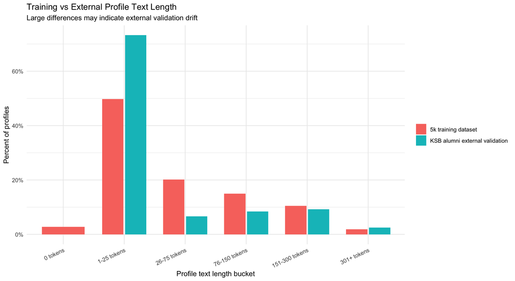

```r
text_length_drift_plot <- text_length_drift |>
  ggplot(aes(x = token_bucket, y = percent, fill = dataset)) +
  geom_col(position = position_dodge(width = 0.75), width = 0.7) +
  scale_y_continuous(labels = label_percent(scale = 1)) +
  labs(
    title = "Training vs External Profile Text Length",
    subtitle = "Large differences may indicate external validation drift",
    x = "Profile text length bucket",
    y = "Percent of profiles",
    fill = NULL
  ) +
  theme_minimal() +
  theme(axis.text.x = element_text(angle = 25, hjust = 1))

text_length_drift_plot
```

```r
ggsave(
  file.path(eda_dir, "text_length_distribution_drift.png"),
  text_length_drift_plot,
  width = 11,
  height = 6
)
```

```r
js_divergence <- function(p, q) {
  eps <- 1e-12
  p <- p + eps
  q <- q + eps
  p <- p / sum(p)
  q <- q / sum(q)
  m <- 0.5 * (p + q)
  0.5 * sum(p * log(p / m)) + 0.5 * sum(q * log(q / m))
}

skill_distribution_wide <- skills_long |>
  filter(skill %in% modeled_skills) |>
  count(dataset, skill, name = "skill_frequency") |>
  complete(dataset, skill = modeled_skills, fill = list(skill_frequency = 0)) |>
  group_by(dataset) |>
  mutate(skill_probability = skill_frequency / sum(skill_frequency)) |>
  ungroup() |>
  select(dataset, skill, skill_probability) |>
  pivot_wider(names_from = dataset, values_from = skill_probability, values_fill = 0)

training_col <- "5k training dataset"
external_col <- "KSB alumni external validation"

skill_distribution_shift_summary <- tibble(
  compared_label_space = "Modeled skills only",
  jensen_shannon_divergence = js_divergence(
    skill_distribution_wide[[training_col]],
    skill_distribution_wide[[external_col]]
  )
)

skill_distribution_shift_summary
```

```
## # A tibble: 1 × 2
##   compared_label_space jensen_shannon_divergence
##   <chr>                                    <dbl>
## 1 Modeled skills only                     0.0395
```

```r
write_csv(
  skill_distribution_shift_summary,
  file.path(eda_dir, "skill_distribution_shift_js_divergence.csv")
)
```

```r
skill_frequency_comparison <- skills_long |>
  filter(skill %in% modeled_skills) |>
  count(dataset, skill, name = "skill_frequency") |>
  group_by(dataset) |>
  mutate(skill_rate = skill_frequency / sum(skill_frequency)) |>
  ungroup() |>
  select(dataset, skill, skill_rate) |>
  pivot_wider(names_from = dataset, values_from = skill_rate, values_fill = 0) |>
  mutate(abs_rate_difference = abs(.data[[training_col]] - .data[[external_col]])) |>
  arrange(desc(abs_rate_difference))

skill_frequency_comparison |>
  slice_head(n = 20)
```

```
## # A tibble: 20 × 4
##    skill        `5k training dataset` KSB alumni external …¹ abs_rate_difference
##    <chr>                        <dbl>                  <dbl>               <dbl>
##  1 microsoft o…               0.0343                 0.0650              0.0307
##  2 microsoft w…               0.0188                 0.0458              0.0270
##  3 microsoft p…               0.0116                 0.0367              0.0251
##  4 microsoft e…               0.0406                 0.0630              0.0224
##  5 strategic p…               0.0251                 0.0108              0.0144
##  6 social media               0.0171                 0.0303              0.0131
##  7 research                   0.0184                 0.0315              0.0131
##  8 public spea…               0.0249                 0.0375              0.0125
##  9 teamwork                   0.0184                 0.0303              0.0118
## 10 strategy                   0.0150                 0.00558             0.00938
## 11 data analys…               0.0216                 0.0291              0.00751
## 12 tableau                    0.00483                0.0120              0.00712
## 13 team buildi…               0.0106                 0.00399             0.00666
## 14 marketing s…               0.0123                 0.00598             0.00636
## 15 budgets                    0.00614                0                   0.00614
## 16 program man…               0.0116                 0.00558             0.00604
## 17 cross-funct…               0.00849                0.00279             0.00570
## 18 analysis                   0.00767                0.00199             0.00568
## 19 process imp…               0.008                  0.00239             0.00561
## 20 customer se…               0.0277                 0.0331              0.00539
## # ℹ abbreviated name: ¹`KSB alumni external validation`
```

```r
write_csv(
  skill_frequency_comparison,
  file.path(eda_dir, "skill_frequency_train_external_comparison.csv")
)
```

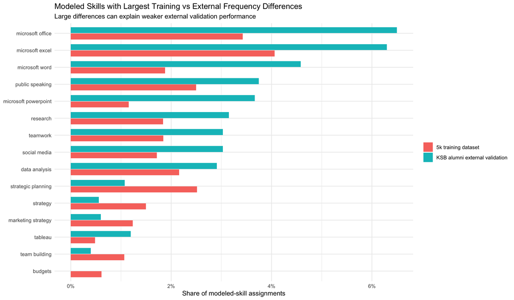

```r
top_shifted_skills <- skill_frequency_comparison |>
  slice_head(n = 15) |>
  select(skill, all_of(training_col), all_of(external_col)) |>
  pivot_longer(cols = -skill, names_to = "dataset", values_to = "skill_rate")

skill_frequency_comparison_plot <- top_shifted_skills |>
  mutate(skill = fct_reorder(skill, skill_rate, .fun = max)) |>
  ggplot(aes(x = skill, y = skill_rate, fill = dataset)) +
  geom_col(position = position_dodge(width = 0.75), width = 0.7) +
  coord_flip() +
  scale_y_continuous(labels = label_percent()) +
  labs(
    title = "Modeled Skills with Largest Training vs External Frequency Differences",
    subtitle = "Large differences can explain weaker external validation performance",
    x = NULL,
    y = "Share of modeled-skill assignments",
    fill = NULL
  ) +
  theme_minimal()

skill_frequency_comparison_plot
```

```r
ggsave(
  file.path(eda_dir, "skill_frequency_train_external_comparison.png"),
  skill_frequency_comparison_plot,
  width = 12,
  height = 7
)
```

# Model Readiness and Risk Diagnostics

**Non-technical explanation.** This section translates the EDA into modeling decisions. It explains what the dataset makes easy, what it makes difficult, and what must be handled carefully before reporting final model results.

**Technical explanation.** The main risks are label imbalance, sparse TF-IDF features, distribution shift, and incomplete external label-space coverage. These risks affect model selection, threshold tuning, and evaluation interpretation.

```r
model_readiness_risks <- tibble::tribble(
  ~risk_area, ~plain_language_meaning, ~technical_meaning, ~recommended_action,
  "Sparse text features",
  "Each profile uses only a small portion of the full vocabulary.",
  "The TF-IDF matrix is high-dimensional and mostly zeros.",
  "Use regularized Logistic Regression as a strong sparse-text baseline; interpret KNN cautiously.",
  "Skill-label imbalance",
  "Some skills appear often while many appear rarely.",
  "Macro metrics will be lower than micro metrics because rare labels are harder to learn.",
  "Report micro-F1, macro-F1, precision, recall, and per-skill performance for top modeled skills.",
  "Zero-skill profiles",
  "Some profiles may not contain any modeled skills.",
  "All-zero target rows provide negative examples and protect against overprediction.",
  "Keep zero-skill profiles unless they are confirmed data-quality errors.",
  "External validation drift",
  "The alumni data may not look exactly like the 5k training data.",
  "Different text length or skill distributions can lower out-of-sample performance.",
  "Explain external validation results separately from internal test results.",
  "Limited modeled label space",
  "The model can only predict skills included in the retained skill list.",
  "External labels outside the modeled skill space are out-of-vocabulary targets.",
  "Report coverage of external labels inside the 100-skill model space before judging performance."
)

model_readiness_risks
```

```
## # A tibble: 5 × 4
##   risk_area          plain_language_meaning technical_meaning recommended_action
##   <chr>              <chr>                  <chr>             <chr>
## 1 Sparse text featu… Each profile uses onl… The TF-IDF matri… Use regularized L…
## 2 Skill-label imbal… Some skills appear of… Macro metrics wi… Report micro-F1, …
## 3 Zero-skill profil… Some profiles may not… All-zero target … Keep zero-skill p…
## 4 External validati… The alumni data may n… Different text l… Explain external …
## 5 Limited modeled l… The model can only pr… External labels … Report coverage o…
```

```r
write_csv(model_readiness_risks, file.path(eda_dir, "model_readiness_risk_table.csv"))
```

**Modeling recommendation.** Based on this EDA, the final modeling workflow should keep Logistic Regression, KNN, and XGBoost, but the evaluation should not rely on accuracy. The correct evaluation frame is multi-label performance: micro precision, micro recall, micro F1, macro precision, macro recall, macro F1, and per-skill diagnostics. Threshold tuning is necessary because the default probability cutoff may not balance precision and recall well for rare skills.

# Key Takeaways

```r
takeaways <- tibble::tribble(
  ~finding, ~why_it_matters_for_skill_extraction,
  "Skill labels are multi-label and highly imbalanced.",
  "F1-micro is useful, but common skills can dominate model performance. Per-skill review is important.",
  "Job descriptions and titles provide the model's main text signal.",
  "Profiles without meaningful descriptions are harder to classify because the model has less evidence.",
  "The external alumni dataset is smaller but directly tests out-of-sample generalization.",
  "This is the best check of whether the training workflow transfers to KSB alumni profiles.",
  "Explicit skill mentions are only part of the problem.",
  "When skill names are not directly in the text, models must infer skills from job duties, titles, industries, and context.",
  "The 100-skill model space should be checked against external labels.",
  "If many external skills are outside the modeled label space, the model cannot predict them regardless of text quality."
)

takeaways
```

```
## # A tibble: 5 × 2
##   finding                                                 why_it_matters_for_s…¹
##   <chr>                                                   <chr>
## 1 Skill labels are multi-label and highly imbalanced.     F1-micro is useful, b…
## 2 Job descriptions and titles provide the model's main t… Profiles without mean…
## 3 The external alumni dataset is smaller but directly te… This is the best chec…
## 4 Explicit skill mentions are only part of the problem.   When skill names are …
## 5 The 100-skill model space should be checked against ex… If many external skil…
## # ℹ abbreviated name: ¹why_it_matters_for_skill_extraction
```

```r
write_csv(takeaways, file.path(eda_dir, "eda_key_takeaways.csv"))
```